# **Assignment:** Classification of … using PCA, Clustering analysis, and ANOVA

#### Mean Perimeter

```r
h4.4 <- lm(
  perimeter_mean ~ as.factor(diagnosis),
  data = data
)
anova(h4.4)
```

|  | Df | Sum Sq | Mean Sq | F value | Pr(>F) |
| --- | --- | --- | --- | --- | --- |
| as.factor(diagnosis) | 1 | 183927.4 | 183927.3559 | 696.3445 | 1.168425e-100 |
| Residuals | 566 | 149499.1 | 264.1327 | NA | NA |

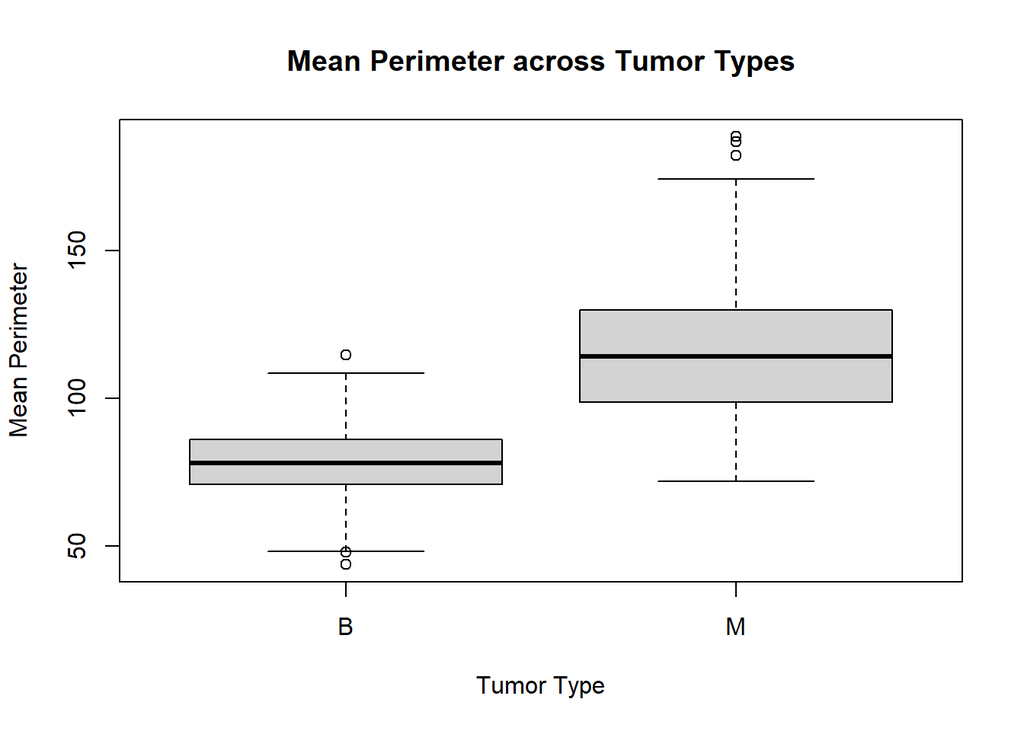

```r
# Boxplot for Mean Perimeter
boxplot(
  perimeter_mean ~ as.factor(diagnosis),
  data = data,
  xlab = "Tumor Type",
  ylab = "Mean Perimeter",
  main = "Mean Perimeter across Tumor Types"
)
```

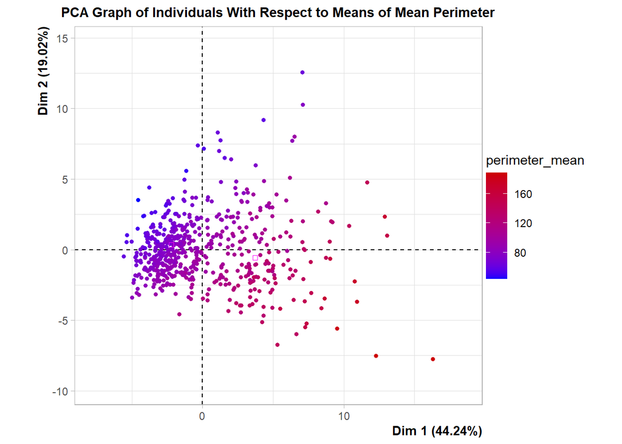

```r
plot.PCA(res.pca,
   choix = "ind",
   hab = "perimeter_mean",
   invisible = c("var"),
   cex = 1,
   autoLab = c("no"),
   title = "PCA Graph of Individuals With Respect to Means of Mean Perimeter",
   label = c("none")
)
```

#### Worst Area

```r
h4.5 <- lm(
  area_worst ~ as.factor(diagnosis),
  data = data
)
anova(h4.5)
```

|  | Df | Sum Sq | Mean Sq | F value | Pr(>F) |
| --- | --- | --- | --- | --- | --- |
| as.factor(diagnosis) | 1 | 98861607 | 98861606.9 | 659.1528 | 5.603959e-97 |
| Residuals | 566 | 84890285 | 149982.8 | NA | NA |

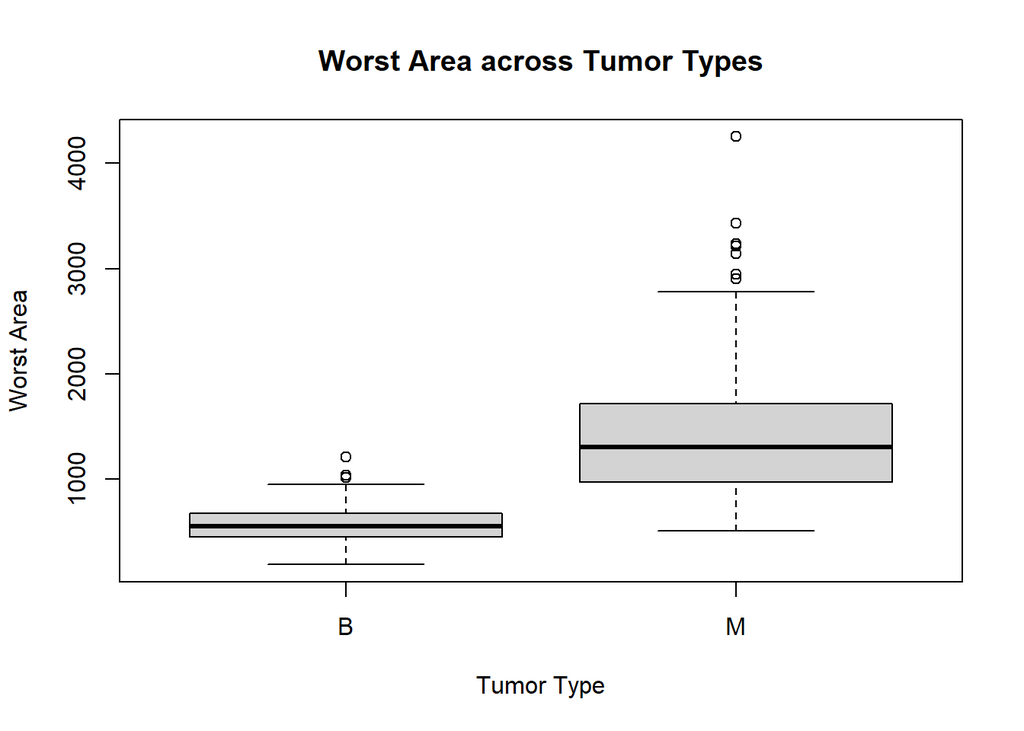

```r
# Boxplot for Worst Area
boxplot(
  area_worst ~ as.factor(diagnosis),
  data = data,
  xlab = "Tumor Type",
  ylab = "Worst Area",
  main = "Worst Area across Tumor Types"
)
```

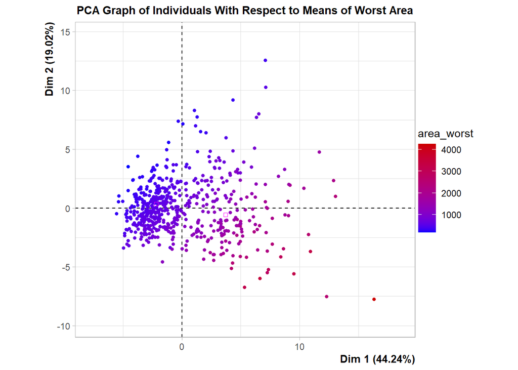

```r
plot.PCA(res.pca,
   choix = "ind",
   hab = "area_worst",
   invisible = c("var"),
   cex = 1,
   autoLab = c("no"),
   title = "PCA Graph of Individuals With Respect to Means of Worst Area",
   label = c("none")
)
```

#### Mean Area

```r
h4.6 <- lm(
  area_mean ~ as.factor(diagnosis),
  data = data
)
anova(h4.6)
```

|  | Df | Sum Sq | Mean Sq | F value | Pr(>F) |
| --- | --- | --- | --- | --- | --- |
| as.factor(diagnosis) | 1 | 35213210 | 35213209.67 | 570.9984 | 8.732999e-88 |
| Residuals | 566 | 34904963 | 61669.55 | NA | NA |

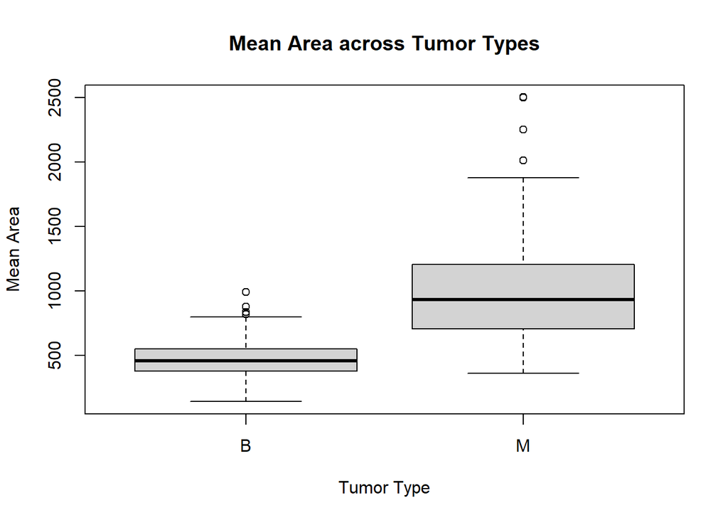

```r
# Boxplot for Mean Area
boxplot(
  area_mean ~ as.factor(diagnosis),
  data = data,
  xlab = "Tumor Type",
  ylab = "Mean Area",
  main = "Mean Area across Tumor Types"
)
```

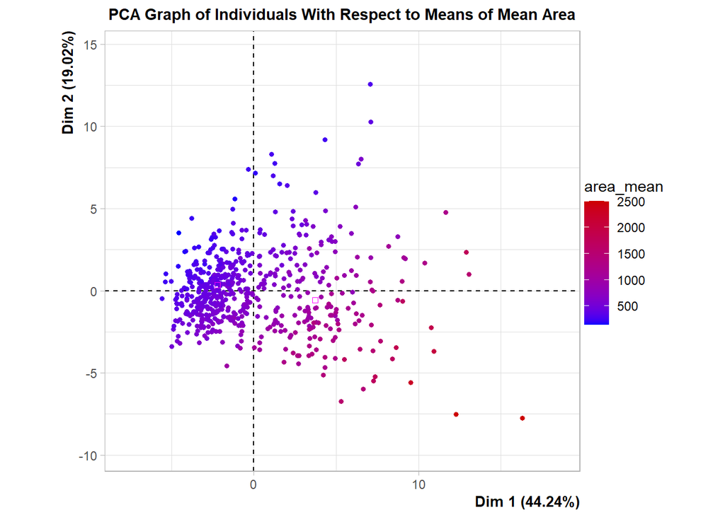

```r
plot.PCA(res.pca,
   choix = "ind",
   hab = "area_mean",
   invisible = c("var"),
   cex = 1,
   autoLab = c("no"),
   title = "PCA Graph of Individuals With Respect to Means of Mean Area",
   label = c("none")
)
```

### **Hypothesis 5:** Mean Fractal dimension between benign and malignant tumors.

- Null Hypothesis (H0): There is no significant difference in Mean Fractal dimension between 2 tumor types.
- Alternative Hypothesis (H1): There is a significant difference in Mean Fractal dimension between 2 tumor types.

#### Test:

ANOVA for Mean Fractal dimension among tumor types.

```r
# ANOVA for Mean Fractal dimension among tumor types.
h5 <- lm(
  fractal_dimension_mean ~ as.factor(diagnosis),
  data = data
)
anova(h5)
```

|  | Df | Sum Sq | Mean Sq | F value | Pr(>F) |
| --- | --- | --- | --- | --- | --- |
| as.factor(diagnosis) | 1 | 5.241495e-06 | 5.241495e-06 | 0.1048553 | 0.7461987 |
| Residuals | 566 | 2.829314e-02 | 4.998788e-05 | NA | NA |

#### Visualization:

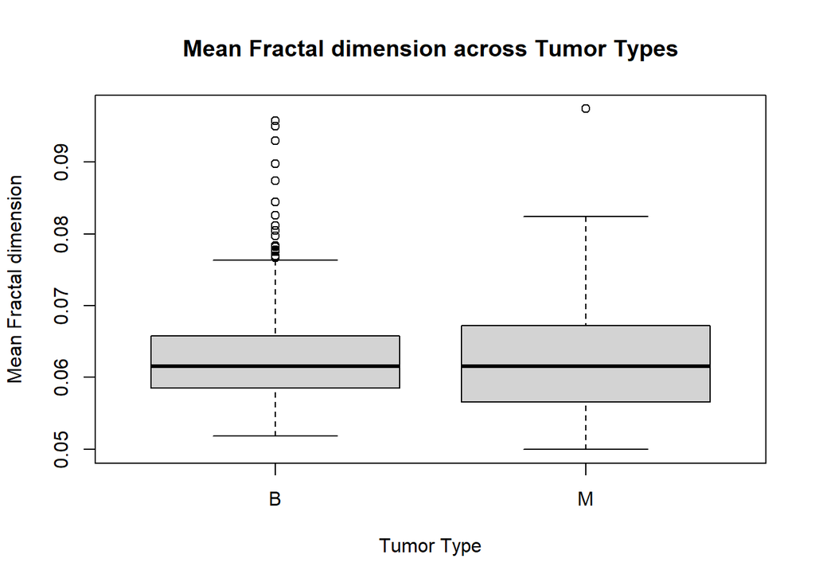

```r
# Boxplot for Mean Fractal dimension
boxplot(
  fractal_dimension_mean~ as.factor(diagnosis),
  data = data,
  xlab = "Tumor Type",
  ylab = "Mean Fractal dimension",
  main = "Mean Fractal dimension across Tumor Types"
)
```

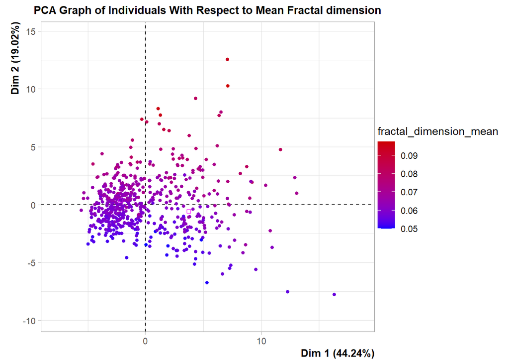

```r
plot.PCA(res.pca,
   choix = "ind",
   hab = "fractal_dimension_mean",
   invisible = c("var"),
   cex = 1,
   autoLab = c("no"),
   title = "PCA Graph of Individuals With Respect to Mean Fractal dimension",
   label = c("none")
)
```

For this variables, the high correlations with the second principal component (Dim.2) does not indicate that this variable varies across different tumor types. It suggests that Mean Fractal dimension significantly contribute to the variability captured by Dim 2. As we can see in the box plot that the mean values of 2 types are no different at all. Therefore we cannot reject the null hypothesis.

### **Hypothesis 6:** All 3 Fractal dimension variables effect on benign and malignant tumors.

- Null Hypothesis (H0): There is no association between the diagnosis of the patients and their combined fractal dimension values.
- Alternative Hypothesis (H1): There is an association between the diagnosis of the patients and their combined fractal dimension values.

#### Test:

ANOVA for 3 Mean Fractal dimension variables among tumor types.

```r
# ANOVA for 3 Mean Fractal dimension variables among tumor types.
h6 <- lm(
  fractal_dimension_mean + fractal_dimension_se + fractal_dimension_worst ~ as.factor(diagnosis),
  data = data
)
anova(h6)
```

|  | Df | Sum Sq | Mean Sq | F value | Pr(>F) |
| --- | --- | --- | --- | --- | --- |
| as.factor(diagnosis) | 1 | 0.02006253 | 0.0200625261 | 31.98417 | 2.468726e-08 |
| Residuals | 566 | 0.35503158 | 0.0006272643 | NA | NA |

# **Conclusion and Discussion**

## **Summary of results**

### Keypoints from analysis and testing

The findings, particularly from PCA, delineate the pivotal role of specific features related to breast mass characteristics derived from digitized images of FNA of breast masses in diagnosing the existing of breast cancer.

With hierarchical clustering analysis, the study further emphasized the heterogeneity in the benign and malignant breast cancer patient groups, as evident by the clear division into two clusters (M or B tumors).

### Statistical significance to the real-world problem

## **Comments and Limitations**

### Recommendations on data quality

In the pursuit of comprehensive data analysis, refining or improving the data table is crucial: firstly, ensuring consistency across columns, especially in categorical variables like ‘diagnose,’ to eliminate discrepancies and ensure accurate labeling. Next, leveraging feature engineering techniques to enhance analysis depth by creating new features or interaction terms based on domain knowledge. Employing cross-validation techniques becomes crucial for predictive modeling, assessing model performance comprehensively for robust findings. Thorough documentation of data preprocessing steps, including handling missing values, ensures transparency and reproducibility. Additionally, establishing a systematic process for ongoing dataset maintenance and updates guarantees sustained data quality and accuracy, especially for periodically updated datasets. These practices collectively fortify the integrity and reliability of the dataset and analyses conducted upon it.

### Data and classification method limitations

PCA is a powerful and flexible technique but it may lose some information and details when reducing data size. This can lead to simplification or distortion of the data and make it more difficult to identify outliers or anomalies. Another disadvantage of PCA is that it can be sensitive to scaling and outliers, which can affect the quality and stability of the results.

For HC, this is a solid, flexible technique that is easy to understand and apply. However, it does not guarantee optimal results or the best possible clustering. The results can depend on the order in which data points are processed, making it difficult to reproduce or generalize them to other data sets with similar characteristics. It cannot handle categorical variables effectively because they cannot be converted to numeric values and thus will not produce meaningful clusters if used in hierarchical clustering algorithms.

Although applying PCA combined with hierarchical clustering and ANOVA makes it easier to visualize taxonomies and select the aspects of the data that contribute the most, this method cannot yield satisfactory classification results and high accuracy. Also, each classification method has its limitations.

Thus, this study has limited capacity for precise interpretation, and require integratation of additional analytical techniques or refining existing ones might enhance the method’s precision, allowing for more precise of breast cancer patients.